# Logistic Regression - Predicting Diabetes Diagnosis

Date: May 13 2024

Hayat Hussein

## Data Cleaning/Preparation

In the Data Cleaning/Preparation part of this project, I first imported the necessary packages for this project such as ggplot2, questionr, dplyr, and Hmisc. I then set my working directory to the INST 452 folder that contained the diabetes.csv that I imported. I then created the height.si variable by multiplying the height variable by 0.0254 through mutate, and created the weight.si variable by multiplying it by 0.453592. After, I created the BMI variable by using the BMI = (weight.si)/(height.si2) formula through the new created variables. Lastly, I recoded a new variable named bmi_categorized to create 4 different conditions (underweight, normal, overweight, and obese). Other values were recoded to NA. I also recoded the insurance variable to include whether or not patients had insurance, government insurance, or private insurance. The smoking variable was also recoded to reflect 3 values of current smokers,individuals who have never smoked, and ex-smokers. After recoding and creating variables, I checked my work using the summary and table functions.

```r
# insert import & data cleaning code here
# import packages
library(ggplot2)
library(questionr)
library(dplyr)
library(Hmisc)
# setting working directory
setwd("/Users/hayathussein/Desktop/INST 452")

# import file
diab <- read.csv("diabetes.csv")

# creating height.si variable
diab <- mutate(diab, height.si = height * 0.0254)

# check work
summary(diab$height.si)

# creating weight.si variable
diab <- mutate(diab, weight.si = weight * 0.453592)

# check work
summary(diab$weight.si)

#creating BMI variable
diab <- mutate(diab, BMI = (weight.si/height.si^2))

# check work
summary(diab$BMI)

# creating BMI categorized variable
diab <- mutate(diab, bmi_categorized = ifelse(BMI< 18.5, "underweight",
                                   ifelse(BMI >= 18.5 & BMI <= 25, "normal",
                                          ifelse(BMI > 25 & BMI <= 30, "overweight",
                                                 ifelse(BMI > 30, "obese", NA)))))
# check work
table(diab$bmi_categorized)

# recode insurance variable
diab <- diab %>% mutate(insurance = ifelse(diab$insurance == 0, "none",
                           ifelse(diab$insurance == 1, "government",
                           ifelse(diab$insurance == 2, "private", insurance))))
# check recode
table(diab$insurance)

# recode smoking variable
diab <- diab %>% mutate(smoking = ifelse(diab$smoking == 1, "current",
                           ifelse(diab$smoking == 2, "never",
                           ifelse(diab$smoking == 3, "ex-smoker", smoking))))
# check recode
table(diab$smoking)
```

[output not shown]

## Exploratory Data Analysis

This dataset contains 403 observations. In the bmi_categorized variable, the percentage of individuals who are obese is 38%. In the gender variable, the percentage of individuals who are female is 58%. In the has diabetes variable, the percentage of individuals who have diabetes is 15%. The mean values for the continuous variables are 46.85 for age and 28.79 for bmi.

```r
# insert exploratory data analysis code here
# number of observations
nrow(diab)
# percentage of observations in each bmi_categorized category
prop.table(table(diab$bmi_categorized))*100
# percentage of observations in each gender category
prop.table(table(diab$gender))*100
# percentage of observations in each diabetes category
prop.table(table(diab$dm))*100
# average age of individuals
mean(diab$age, na.rm = T)
# average BMI of individuals
mean(diab$BMI, na.rm = T)
```

[output not shown]

## Data Visualization

Barchart #1 displays that individuals with government provided insurance have the highest frequency compared to the other types of insurance. Barchart #2 displays that individuals who have never smoked has the highest frequency compared to the other types of smokers. Scatterplot #3 shows a weak linear relationship between the body mass index variable and the cholesterol variable. Histogram #4 shows the highest peak in the age variable, between individuals ages 25 through 50.

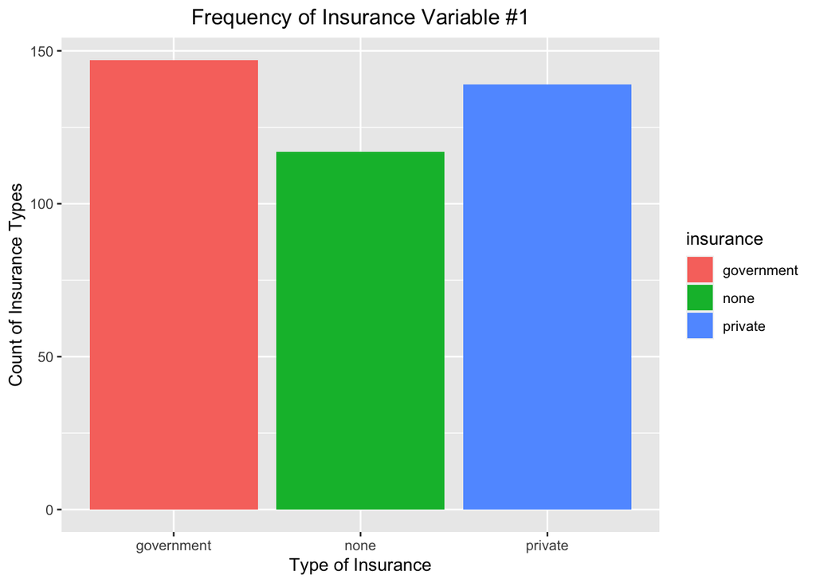

```r
# insert logistic regression code
# insurance bar chart
ggplot(data=diab) + aes(x=insurance, fill=insurance) + geom_bar()+
   labs(title="Frequency of Insurance Variable #1",x="Type of Insurance", y="Count of Insurance Types") + theme(plot.title = element_text(hjust = 0.5))
```

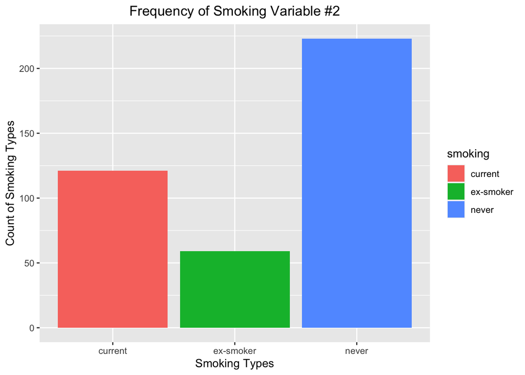

```r
# smoking bar chart
ggplot(data=diab) + aes(x=smoking, fill=smoking) + geom_bar()+
   labs(title="Frequency of Smoking Variable #2",x="Smoking Types", y="Count of Smoking Types") + theme(plot.title = element_text(hjust = 0.5))
```

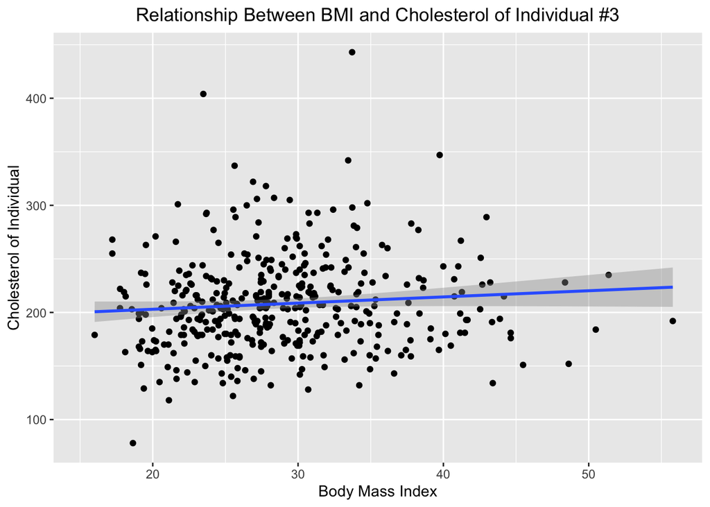

```r
# scatterplot showing the relationship between BMI and Cholesterol
ggplot(data=diab) + aes(x=BMI, y=chol) + geom_point() +  geom_smooth(method=lm) +
   labs(title="Relationship Between BMI and Cholesterol of Individual #3",x="Body Mass Index", y="Cholesterol of Individual") + theme(plot.title = element_text(hjust = 0.5))
```

```r
# calculate the correalation coefficient
cor.test(diab$BMI, diab$chol, method = "pearson", conf.level = 0.95)
```

```
##
##  Pearson's product-moment correlation
##
## data:  diab$BMI and diab$chol
## t = 1.712, df = 394, p-value = 0.08768
## alternative hypothesis: true correlation is not equal to 0
## 95 percent confidence interval:
##  -0.01272251  0.18292861
## sample estimates:
##        cor
## 0.08593146
```

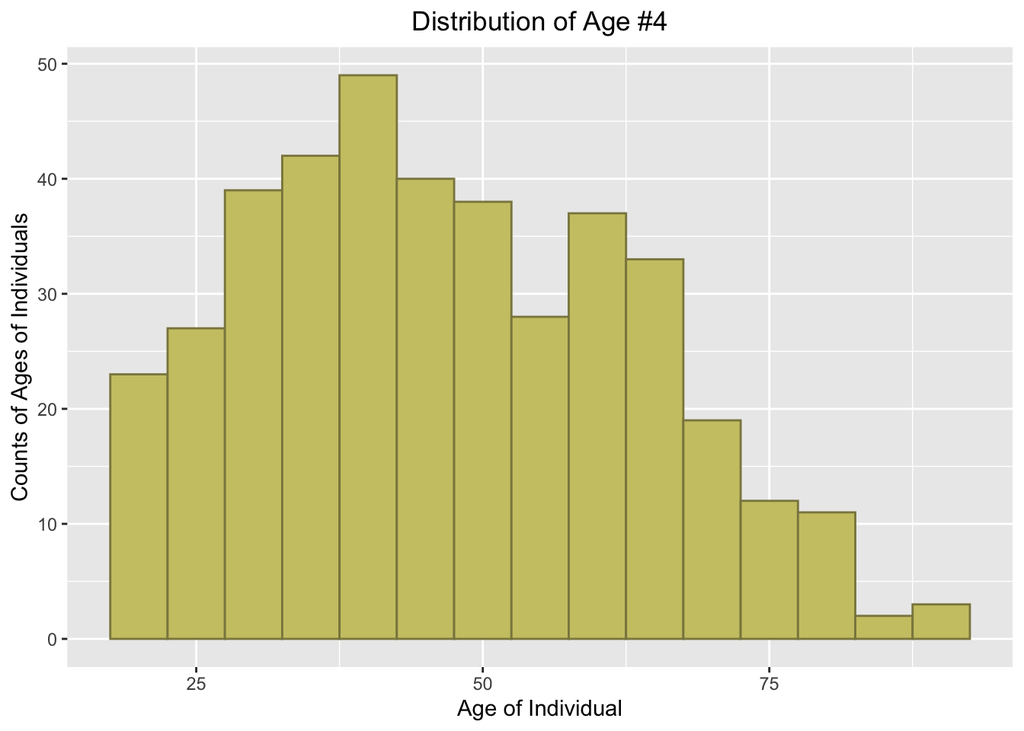

```r
# histogram of age variable
ggplot(data=diab) + aes(x=age) + geom_histogram(fill="khaki3", color="khaki4", binwidth = 5)+
   labs(title="Distribution of Age #4",x="Age of Individual", y="Counts of Ages of Individuals") + theme(plot.title = element_text(hjust = 0.5))
```

## Logistic Regression Results

A 1-year increase in age causes the log odds of diabetes to increase by 0.055454, holding the other independent variables constant. A change in the gender from female to male increases the log odds of diabetes by 0.244852, holding all other variables constant. A 1-unit increase in BMI causes the log odds of diabetes to increase by 0.073879, holding all the other independent variables constant.

```r
fit1 <- glm(dm ~ age + factor(gender) + BMI, data = diab, family = "binomial")

summary(fit1)
```

[output not shown]